# Beer & Brewery Report

Quentin, Sita, Olha, Tosin

2/19/2018

*Though enjoying a quality craft beer is simple enough to do, brewing it to perfection is quite another story. It can take years of effort and lots of batches of beer to create a delicious brew. The more you understand about the beer you are drinking, the more you can fully appreciate it in all of its glory.*

*Two important measurements of beer that you should know are ABV and IBU. Figuring out what they mean and how they relate to beer can help you to better understand our analysis below and your own preference for beer and the beers behind the bar.*

[figure not shown]

### What Does ABV Mean?

ABV stands for Alcohol By Volume and is usually listed as a percentage. By law in the United States, the ABV must be listed on each beer to give customers an idea about how much alcohol is in each brew.

This percentage lets you know how much of your beer is alcohol and how much is other stuff, like water. Simply put, the higher the ABV, the more drunk you’ll get. Beer can be anywhere between 2% to 12% ABV, though you’ll generally find it in the 4% to 6% range.

So how does a beer become alcoholic? During the brewing process, yeast transforms sugar into alcohol. Brewers take samples of the beer while its undergoing this process, and make changes to the batch in order to make it as strong as they’d like.

### What Does IBU Mean?

Like ABV, IBU (International Bitterness Units) is another common measurement for beer. Rather than telling us how much alcohol there is, IBU measures the bitterness from hops in a beer on a scale of 0 to 100. In more technical terms, IBU gauges the isomerized alpha acids from hops in a beer in parts per million. Very hoppy beers, like imperial IPAs, can reach 80 BU.

Though IBUs can help you better understand what type of beer you like in terms of bitterness, it’s important to note that the bitterness of beer is also affected by malts. Beer with a high IBU, like stouts, might not taste very bitter at all because of their sweet malts. Instead of relying on IBU to perceive the bitterness of a beer, use it to gauge your preferences. Try to look at the IBU of your favorite beers to understand what range is your favorite.

***http://berghoffbeer.com

# Case Study 1

### How many breweries are present in each state?

Following code generates a data file that represents the total no. of breweries present in each state (US Specifically).

```r
#import breweries file
Breweries <- read.csv("data/Breweries.csv")
#inspecting the dataset
str(Breweries)
```

```
## 'data.frame':    558 obs. of  4 variables:
##  $ Brew_ID: int  1 2 3 4 5 6 7 8 9 10 ...
##  $ Name   : Factor w/ 551 levels "10 Barrel Brewing Company",..: 355 12 266 319 201 136 227 477 59 491 ...
##  $ City   : Factor w/ 384 levels "Abingdon","Abita Springs",..: 228 200 122 299 300 62 91 48 152 136 ...
##  $ State  : Factor w/ 51 levels " AK"," AL"," AR",..: 24 18 20 5 5 41 6 23 23 23 ...
```

```r
#sort the data by state
library(dplyr)
breweriesOrderedByState <- arrange(Breweries, desc(Breweries$State))
# use table function to get a count of breweries
breweriesbystate <- table(Breweries$State)
# change table to dataframe
breweriesbystate <- as.data.frame(breweriesbystate)
str(breweriesbystate)
```

```
## 'data.frame':    51 obs. of  2 variables:
##  $ Var1: Factor w/ 51 levels " AK"," AL"," AR",..: 1 2 3 4 5 6 7 8 9 10 ...
##  $ Freq: int  7 3 2 11 39 47 8 1 2 15 ...
```

```r
# assign names to columns
names(breweriesbystate) <- c("State","Total Breweries")
print(breweriesbystate)
```

```
##    State Total Breweries
## 1     AK               7
## 2     AL               3
## 3     AR               2
## 4     AZ              11
## 5     CA              39
## 6     CO              47
## 7     CT               8
## 8     DC               1
## 9     DE               2
## 10    FL              15
## 11    GA               7
## 12    HI               4
## 13    IA               5
## 14    ID               5
```

[output cut: 37 more lines]

Observed that the state of Colorado has the highest number of breweries followed by California. Also, the least number of breweries are present in four states, District of Columbia, North Dakota, South Dakota and West Virginia

### Merge beer data with the breweries data. Print the first 6 observations and the last six observations to check the merged file.

Following code generates a merged data file for the breweries and the beers available in them

```r
#load the beers file
Beers <- read.csv("data/Beers.csv")
# inspect dataset
str(Beers)
```

```
## 'data.frame':    2410 obs. of  7 variables:
##  $ Name      : Factor w/ 2305 levels "#001 Golden Amber Lager",..: 1638 577 1704 1842 1819 268 1160 758 1093 486 ...
##  $ Beer_ID   : int  1436 2265 2264 2263 2262 2261 2260 2259 2258 2131 ...
##  $ ABV       : num  0.05 0.066 0.071 0.09 0.075 0.077 0.045 0.065 0.055 0.086 ...
##  $ IBU       : int  NA NA NA NA NA NA NA NA NA NA ...
##  $ Brewery_id: int  409 178 178 178 178 178 178 178 178 178 ...
##  $ Style     : Factor w/ 100 levels "","Abbey Single Ale",..: 19 18 16 12 16 80 18 22 18 12 ...
##  $ Ounces    : num  12 12 12 12 12 12 12 12 12 12 ...
```

```r
names(Breweries)
```

```
## [1] "Brew_ID" "Name"    "City"    "State"
```

```r
names(Beers)
```

```
## [1] "Name"       "Beer_ID"    "ABV"        "IBU"        "Brewery_id"
## [6] "Style"      "Ounces"
```

```r
#rename columns
names(Breweries) <- c("Brewery_id","Brewery_Name", "City", "State" )
names(Beers) <- c("Beer_Name","Beer_ID","ABV","IBU","Brewery_id","Style","Ounces")
#common variable data is Brewery_id
breweriesandbeers <- merge(Breweries,Beers, by=c("Brewery_id"), all=TRUE)
str(breweriesandbeers) # 2410 10
```

```
## 'data.frame':    2410 obs. of  10 variables:
##  $ Brewery_id  : int  1 1 1 1 1 1 2 2 2 2 ...
##  $ Brewery_Name: Factor w/ 551 levels "10 Barrel Brewing Company",..: 355 355 355 355 355 355 12 12 12 12 ...
##  $ City        : Factor w/ 384 levels "Abingdon","Abita Springs",..: 228 228 228 228 228 228 200 200 200 200 ...
##  $ State       : Factor w/ 51 levels " AK"," AL"," AR",..: 24 24 24 24 24 24 18 18 18 18 ...
##  $ Beer_Name   : Factor w/ 2305 levels "#001 Golden Amber Lager",..: 1640 1926 1525 802 1258 2185 71 458 1218 43 ...
##  $ Beer_ID     : int  2689 2688 2687 2692 2691 2690 2683 2686 2685 2684 ...
##  $ ABV         : num  0.06 0.06 0.056 0.045 0.049 0.048 0.042 0.08 0.125 0.077 ...
##  $ IBU         : int  38 25 47 50 26 19 42 68 80 25 ...
##  $ Style       : Factor w/ 100 levels "","Abbey Single Ale",..: 83 22 57 16 77 48 18 12 46 77 ...
##  $ Ounces      : num  16 16 16 16 16 16 16 16 16 16 ...
```

```r
head(breweriesandbeers)
```

```
##   Brewery_id       Brewery_Name        City State     Beer_Name Beer_ID
## 1          1 NorthGate Brewing  Minneapolis    MN       Pumpion    2689
## 2          1 NorthGate Brewing  Minneapolis    MN    Stronghold    2688
## 3          1 NorthGate Brewing  Minneapolis    MN   Parapet ESB    2687
## 4          1 NorthGate Brewing  Minneapolis    MN  Get Together    2692
## 5          1 NorthGate Brewing  Minneapolis    MN Maggie's Leap    2691
## 6          1 NorthGate Brewing  Minneapolis    MN    Wall's End    2690
##     ABV IBU                               Style Ounces
## 1 0.060  38                         Pumpkin Ale     16
## 2 0.060  25                     American Porter     16
## 3 0.056  47 Extra Special / Strong Bitter (ESB)     16
## 4 0.045  50                        American IPA     16
## 5 0.049  26                  Milk / Sweet Stout     16
## 6 0.048  19                   English Brown Ale     16
```

```r
tail(breweriesandbeers)
```

```
##      Brewery_id                  Brewery_Name          City State
## 2405        556         Ukiah Brewing Company         Ukiah    CA
## 2406        557       Butternuts Beer and Ale Garrattsville    NY
## 2407        557       Butternuts Beer and Ale Garrattsville    NY
## 2408        557       Butternuts Beer and Ale Garrattsville    NY
## 2409        557       Butternuts Beer and Ale Garrattsville    NY
## 2410        558 Sleeping Lady Brewing Company     Anchorage    AK
##                      Beer_Name Beer_ID   ABV IBU                   Style
## 2405             Pilsner Ukiah      98 0.055  NA         German Pilsener
## 2406         Porkslap Pale Ale      49 0.043  NA American Pale Ale (APA)
## 2407           Snapperhead IPA      51 0.068  NA            American IPA
## 2408         Moo Thunder Stout      50 0.049  NA      Milk / Sweet Stout
## 2409  Heinnieweisse Weissebier      52 0.049  NA              Hefeweizen
## 2410 Urban Wilderness Pale Ale      30 0.049  NA        English Pale Ale
##      Ounces
## 2405     12
## 2406     12
## 2407     12
## 2408     12
## 2409     12
## 2410     12
```

```r
write.csv(breweriesandbeers,file ="data/breweriesandbeers.csv", row.names = FALSE, quote=FALSE)
```

### Report the number of `NA's` In each column.

```r
#variable NA_count will represent the number of NA's in each column
NA_count <- colSums(is.na(breweriesandbeers))
NA_count
```

```
##   Brewery_id Brewery_Name         City        State    Beer_Name
##            0            0            0            0            0
##      Beer_ID          ABV          IBU        Style       Ounces
##            0           62         1005            0            0
```

The number of NA’s in the column ABV: 62, IBU: 1005, the rest columns: 0.

### Which state has the maximum alcoholic (ABV) beer? Which state has the most bitter (IBU) beer?

```r
#Lets move NAs from the ABV column and then check max ABV using function order (we want to see the whole line which contains this element)
#Variable ABV_NOna will represent data set without NAs elements in the column ABV and ABV_NOna_ordered will represent ordered data set by column ABV without NAs elements.
ABV_NOna <- subset(x=breweriesandbeers, !is.na(breweriesandbeers$ABV))
ABV_NOna_ordered <- ABV_NOna[order(ABV_NOna$ABV),]
tail(ABV_NOna_ordered,1)
```

```
##     Brewery_id            Brewery_Name    City State
## 384         52 Upslope Brewing Company Boulder    CO
##                                                Beer_Name Beer_ID   ABV IBU
## 384 Lee Hill Series Vol. 5 - Belgian Style Quadrupel Ale    2565 0.128  NA
##                Style Ounces
## 384 Quadrupel (Quad)   19.2
```

```r
#Lets move NAs from the IBU column and then check max IBU using function order (we want to see the whole line which contains this element)
#Variable IBU_NOna will represent data set without NAs elements in the column IBU
IBU_NOna <- subset(x=breweriesandbeers, !is.na(breweriesandbeers$IBU))
IBU_NOna_ordered <- IBU_NOna[order(IBU_NOna$IBU),]
tail(IBU_NOna_ordered,1)
```

```
##      Brewery_id            Brewery_Name    City State
## 1857        375 Astoria Brewing Company Astoria    OR
##                      Beer_Name Beer_ID   ABV IBU
## 1857 Bitter Bitch Imperial IPA     980 0.082 138
##                               Style Ounces
## 1857 American Double / Imperial IPA     12
```

```r
#In this way we gave the answer on the question 5 and still keeping all NAs in final dataset "breweriesandbeers" in case we will need them.
```

Based on data we have State Colorado (CO) has the maximum alcoholic (Lee Hill Series Vol. 5 - Belgian Style Quadrupel Ale: ABV = 0.128) beer. State Oregon (OR) has the most bitter (Bitter Bitch Imperial IPA: IBU = 138) beer.

[figure not shown]

[figure not shown]

[*Interesting: Samuel Adams claims the title of brewing the strongest naturally-fermented beer in the world. In 2012, Utopia was released at 29% ABV (58 proof), though some of its barrels clocked in at 33% ABV. Yes, you read that right.Location: Massachusetts, United States*](http://berghoffbeer.com/blog/5-strongest-naturally-fermented-beers-world/)

### Compute the median alcohol content and international bitterness unit for each state. Plot a bar chart to compare.

```r
library(ggplot2)
med.abv <- tapply(ABV_NOna$ABV, ABV_NOna$State, median)
med.abv
```

```
##     AK     AL     AR     AZ     CA     CO     CT     DC     DE     FL
## 0.0560 0.0600 0.0520 0.0550 0.0580 0.0605 0.0600 0.0625 0.0550 0.0570
##     GA     HI     IA     ID     IL     IN     KS     KY     LA     MA
## 0.0550 0.0540 0.0555 0.0565 0.0580 0.0580 0.0500 0.0625 0.0520 0.0540
##     MD     ME     MI     MN     MO     MS     MT     NC     ND     NE
## 0.0580 0.0510 0.0620 0.0560 0.0520 0.0580 0.0550 0.0570 0.0500 0.0560
##     NH     NJ     NM     NV     NY     OH     OK     OR     PA     RI
## 0.0550 0.0460 0.0620 0.0600 0.0550 0.0580 0.0600 0.0560 0.0570 0.0550
##     SC     SD     TN     TX     UT     VA     VT     WA     WI     WV
## 0.0550 0.0600 0.0570 0.0550 0.0400 0.0565 0.0550 0.0555 0.0520 0.0620
##     WY
## 0.0500
```

```r
med.ibu <- tapply(IBU_NOna$IBU, IBU_NOna$State, median)
med.ibu
```

```
##   AK   AL   AR   AZ   CA   CO   CT   DC   DE   FL   GA   HI   IA   ID   IL
## 46.0 43.0 39.0 20.5 42.0 40.0 29.0 47.5 52.0 55.0 55.0 22.5 26.0 39.0 30.0
##   IN   KS   KY   LA   MA   MD   ME   MI   MN   MO   MS   MT   NC   ND   NE
## 33.0 20.0 31.5 31.5 35.0 29.0 61.0 35.0 44.5 24.0 45.0 40.0 33.5 32.0 35.0
##   NH   NJ   NM   NV   NY   OH   OK   OR   PA   RI   SC   SD   TN   TX   UT
## 48.5 34.5 51.0 41.0 47.0 40.0 35.0 40.0 30.0 24.0 30.0   NA 37.0 33.0 34.0
##   VA   VT   WA   WI   WV   WY
## 42.0 30.0 38.0 19.0 57.5 21.0
```

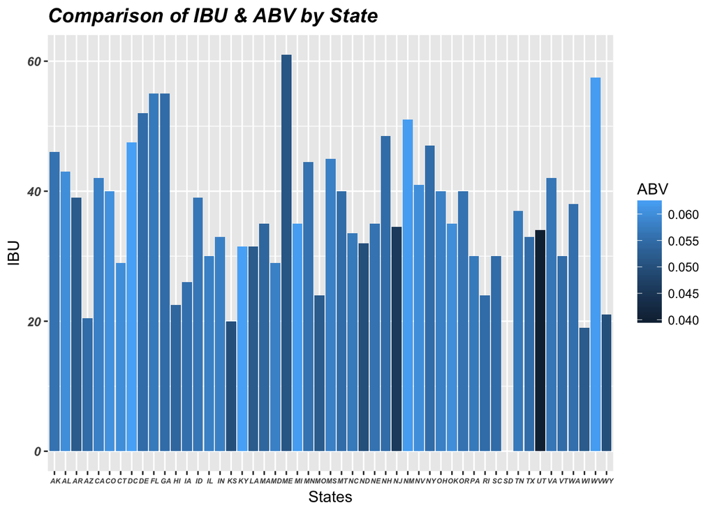

```r
median_abv <- as.data.frame.table(med.abv)
median_ibu <- as.data.frame.table(med.ibu)
colnames(median_abv)[1] <- "States"
colnames(median_ibu)[1] <- "States"

data <- merge(median_abv, median_ibu, by="States", all = TRUE)
colnames(data)[3] <- "IBU"
colnames(data)[2] <- "ABV"

mytheme <- theme(plot.title = element_text(face = "bold.italic",
                 size= 14, color = "black"), axis.text.x = element_text(size = 5, face ="bold.italic"), axis.text.y = element_text(face = "bold.italic"))
ggplot(data = data, aes(x = States, y = IBU, fill = ABV)) +
    geom_bar(stat = "identity") +
    labs(title = "Comparison of IBU & ABV by State") +
     mytheme
```

### Summary statistics for the ABV variable.

Here we examine a summary of the ABV data in our `Beers.csv` dataset.

```r
summary(breweriesandbeers$ABV)
```

```
##    Min. 1st Qu.  Median    Mean 3rd Qu.    Max.    NA's
## 0.00100 0.05000 0.05600 0.05977 0.06700 0.12800      62
```

Min. ABV is 0.001, Mean value is 0.05977 and Max. ABV is 0.128.

### Is there an apparent relationship between the bitterness of the beer and its alcoholic content?

In order for us to better examine whether or not there is a relationship between the bitterness of the beer and its alcoholic content we will take a look at the `ABV` and `IBU` data. The `ABV` data represents our alcohol volume measurement within the beer itself, and the `IBU` represents the international bitterness measurement of the beer. Before we can plot these we must create a subset of this data set.

```r
#create a subset for the variables ABV and IBU as they are our variables fo interest
bitter_vs_alc <- subset(Beers, subset = is.na(IBU) == FALSE, select = c(ABV, IBU))

head(bitter_vs_alc)
```

```
##      ABV IBU
## 15 0.061  60
## 22 0.099  92
## 23 0.079  45
## 25 0.044  42
## 26 0.049  17
## 27 0.049  17
```

Now that we have prepared our data we will plot it to better understand the relationship.

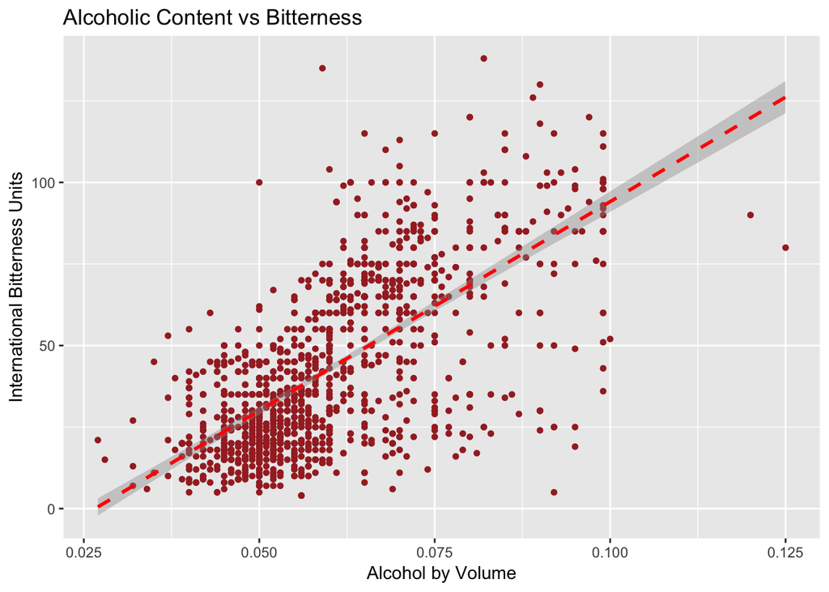

```r
library(ggplot2)

ggplot(data=bitter_vs_alc, aes(x=ABV, y=IBU)) +
  geom_point(pch = 20, color = "brown", size=2) +
  geom_smooth(method="lm", color="red", linetype=2) +
  labs(title="Alcoholic Content vs Bitterness",
       x="Alcohol by Volume", y="International Bitterness Units")
```

Based on our chart above we can conclude that there is a positive relationship between the alcohol content and bitterness units based on our line present through the graph. We can also see that as bitterness increases we also expect to see an increase in the alcohol levels. This suggests that if a beer has a bitter taste, the alcohol content could be high for that specific beer.

Lets check correlation value using next code:

```r
cor.test(breweriesandbeers$ABV,breweriesandbeers$IBU)
```

```
##
##  Pearson's product-moment correlation
##
## data:  breweriesandbeers$ABV and breweriesandbeers$IBU
## t = 33.863, df = 1403, p-value < 2.2e-16
## alternative hypothesis: true correlation is not equal to 0
## 95 percent confidence interval:
##  0.6407982 0.6984238
## sample estimates:
##       cor
## 0.6706215
```

`p-value < 2.2e-16` means we should reject the null hypothesis that true correlation is equal to 0. We can conclude that alcoholic content (ABV) and bitterness (IBU) are significantly correlated with a correlation coefficient of `0.67` and p-value of `2.2*10^{-16}`.

### Conclusion

Beers & Breweries are a big part of American culture as we have seen from the data. We’ve seen all of the states that contain multiple breweries and we broke them down by their ABV and their IBU. We also examined the median alcohol volume and its corresponding median bitterness measurement by state. We saw that Colorado had the most breweries of all the States followed by California. Finally, we examined whether or not IBU and ABV were correlated. Based on this case study we can conclude that the ideal place for having a brewery has been Colorado, and for new Beer drinkers it is probably ideal for them to start with a beer that has a lower IBU as it will usually result in that beer having a lower alcohol volume.